# 복습문제

### 1-1.“news”를 불러와서 명사추출을 해보세요.(복습과제에서는 세종사전을 사용해봅시다!)

### hint : useSejongDic()

### 1-2. 1-1에서 나온 결과를 보고, 올바르지 않게 추출된 명사를 직접 수정해보세요.(hint:괄호, 큰따옴표, 숫자 제거)

### (단, 숫자만으로 이루어진 것을 제거할 때는 str_extract 함수를 이용해보세요!)

### 2-1 세션때 천처리했던 기사 5개와 1번에서 전처리한 기사(총 6개)를 사용하여 tf-idf Matrix를 만들어보세요

#### (조건: weight=tf-idf, 구두점&숫자제거, 글자수 2~5)

### 2-2 위에서 구한 Matrix를 활용하여 문서1과 다른 문서들 간의 코사인 유사도를 구하고 비슷한 문서 순으로 나열해보세요

#### 코사인 유사도는 다음 함수를 사용해주세요

```r
###library(lsa)
###cos_1_2 = cosine(a[,1], a[,2])
```

### 3.주어진 데이터는 가수 아이유와 최근 1년동안 공동 작업한 뮤지션, 그 뮤지션과 공동 작업한 뮤지션의 정보를 담고 있습니다. 다음과 같이 데이터를 불러오세요.

```r
# 데이터 읽어오기 ,아이유와 최근 1년 동안 공동 작업한 뮤지션 그리고 그 뮤지션과 공동 작업한 뮤지션 정보
setwd("C:/Users/강한얼/Documents/MyRHome")
link<- read.csv("featuring.csv")
head(link)
```

```
##       from       to          type weight X
## 1   아이유 G-DRAGON Collaboration      2
## 2 에픽하이   아이유     featuring      1
## 3 에픽하이     오혁     featuring      3
## 4   아이유     오혁 Collaboration      1
## 5    HIGH4   아이유     featuring      2 `
## 6 에픽하이     MINO Collaboration      3
```

```r
#노드 정보 추가하기, group or solo
nodes<-data.frame('name'=c("아이유","에픽하이","HIGH4","MINO","사이먼 도미닉","G-DRAGON","오혁","더콰이엇","수현"),'type'=c("solo","group","group","solo","solo","solo","solo","solo","solo"))
head(nodes)
```

```
##            name  type
## 1        아이유  solo
## 2      에픽하이 group
## 3         HIGH4 group
## 4          MINO  solo
## 5 사이먼 도미닉  solo
## 6      G-DRAGON  solo
```

### 3-1. 주어진 데이터를 그래프 객체로 변환하고, 가장 기초적인 네트워크 시각화를 해보세요(옵션 x).

```
## + 9/9 vertices, named, from 70a7e7b:
## [1] 아이유        에픽하이      HIGH4         MINO          사이먼 도미닉
## [6] G-DRAGON      오혁          더콰이엇      수현
```

```
## + 12/12 edges from 70a7e7b (vertex names):
##  [1] 아이유       ->G-DRAGON      에픽하이     ->아이유
##  [3] 에픽하이     ->오혁          아이유       ->오혁
##  [5] HIGH4        ->아이유        에픽하이     ->MINO
##  [7] 에픽하이     ->사이먼 도미닉 에픽하이     ->더콰이엇
##  [9] 에픽하이     ->수현          MINO         ->사이먼 도미닉
## [11] MINO         ->더콰이엇      사이먼 도미닉->더콰이엇
```

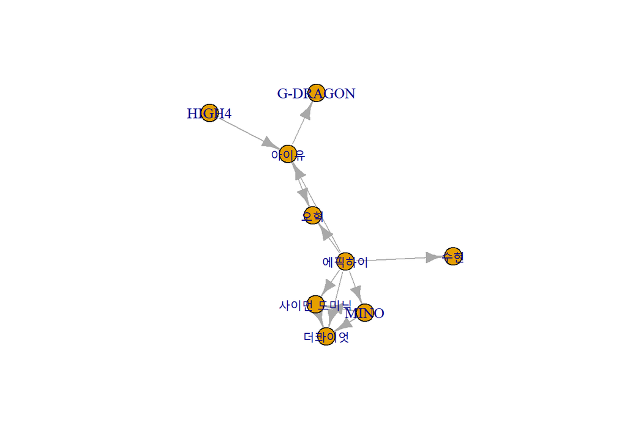

### 3-2 이번에는, 솔로가수이면 lightblue, group이면 gold ,링크 관계가 collaboration이면 =“grey” , featuring이면 “magenta” 로 컬러 옵션을 추가 해보세요.

### 또한 범례를 추가해 보세요. * 주어진 그림과 똑같을 필요는 없습니다.

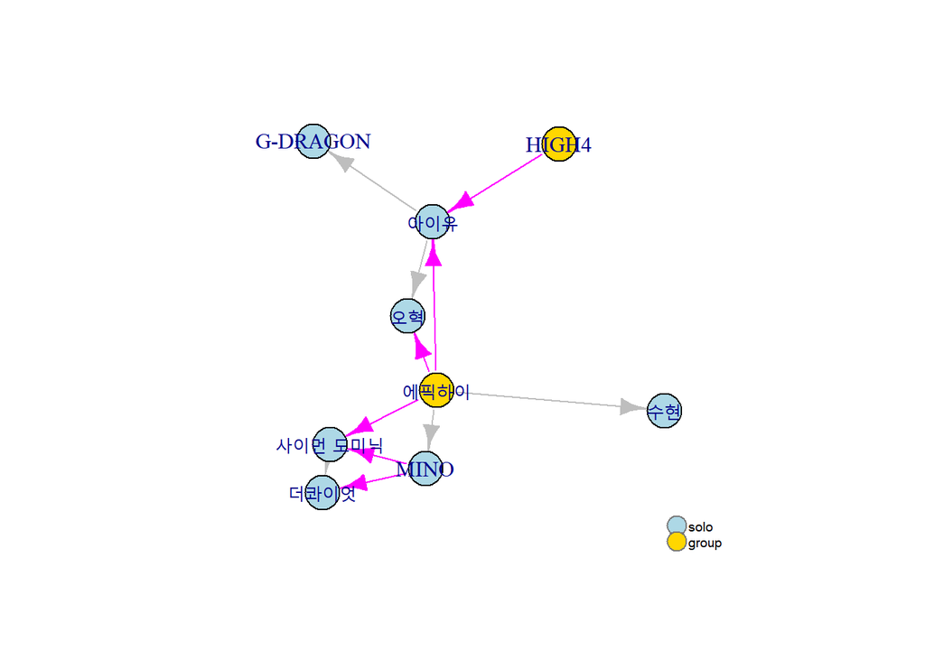

### 3-3 마지막으로 주어진 네트워크가 하나의 인적 네트워크라 생각하고 ,중심성을 다음과 같이 계산해 보세요. (연결 중심성, 고유벡터 중심성, 매개 중심성 계산)

```
##               net_dgree  net_eigen net_between
## 아이유            0.500 0.11239964  0.07142857
## 에픽하이          0.750 0.83416616  0.00000000
## HIGH4             0.125 0.02157086  0.00000000
## MINO              0.375 0.87122191  0.00000000
## 사이먼 도미닉     0.375 1.00000000  0.00000000
## G-DRAGON          0.125 0.02157086  0.00000000
## 오혁              0.250 0.25091545  0.00000000
## 더콰이엇          0.375 0.89422016  0.00000000
## 수현              0.125 0.16008668  0.00000000
```